# R Notebook

FIRST: run the stats_proj_sablefish scriptfile.

For some reason, it’s not working well with Rnotebook.

So, run that scriptfile first, and now I’ll try working in R notebook.

Treat the data as geostatisitcal data conduct a Spatial Logistic Regression and use the spBayes package

My datafile name is: Sable_geo

So, logistic regression means we either use 0 or 1 for the data. I think I’ll need to manipulate the Sable_geo data to reflect this.

```r
names(Sable_geo)
```

```
$coords
[1] "LONGITUDE" "LATITUDE"

$data
[1] "data"
```

```r
Sable_geo$data
```

[output not shown]

[output cut: 86 more lines]

```r
length(Sable_geo$data)
```

```
[1] 1150
```

```r
#I can do this with a for loop.. or with mutate
Sable_geo_df_2 <- as.data.frame(Sable_geo)
Sable_geo_df_binary <- Sable_geo_df_2 %>% mutate(data = ifelse(data>0, 1, 0))
length(Sable_geo_df_binary$data)
```

```
[1] 1150
```

```r
Sable_geo_binary <- as.geodata(Sable_geo_df_binary)
```

```
as.geodata: 3 replicated data locations found.
 Consider using jitterDupCoords() for jittering replicated locations.
WARNING: there are data at coincident or very closed locations, some of the geoR's functions may not work.
 Use function dup.coords() to locate duplicated coordinates.
 Consider using jitterDupCoords() for jittering replicated locations
```

```r
##warning that there's some overlapping locations. I shold think about getting rid of duplicates?
```

Ok so now I have a binary dataframe and binary geodataframe. We can do logistic regression on this… It uses the logit tranformation

Might be useful to do this as bayes and not based methods Where’s my plot of alaska?? IDK There’s a ggplot way. I think I can skip this Reference: https://hughst.github.io/week-6/

Ooh, I do make a model! A linear model or a glm? GLM

```r
names(Sable_geo_df_binary)
```

```
[1] "LONGITUDE" "LATITUDE"  "data"
```

```r
glm_mod_1 <- glm(data ~ LONGITUDE + LATITUDE, data=Sable_geo_df_binary, family=binomial())
summary(glm_mod_1)
```

```
Call:
glm(formula = data ~ LONGITUDE + LATITUDE, family = binomial(),
    data = Sable_geo_df_binary)

Deviance Residuals:
    Min       1Q   Median       3Q      Max
-0.9646  -0.6844  -0.3786  -0.1752   3.1491

Coefficients:
            Estimate Std. Error z value Pr(>|z|)
(Intercept) 52.98190    9.03735   5.863 4.56e-09 ***
LONGITUDE    0.20043    0.02362   8.485  < 2e-16 ***
LATITUDE    -1.05974    0.17431  -6.080 1.21e-09 ***
---
Signif. codes:  0 ‘***’ 0.001 ‘**’ 0.01 ‘*’ 0.05 ‘.’ 0.1 ‘ ’ 1

(Dispersion parameter for binomial family taken to be 1)

    Null deviance: 935.04  on 1149  degrees of freedom
Residual deviance: 818.41  on 1147  degrees of freedom
AIC: 824.41

Number of Fisher Scoring iterations: 6
```

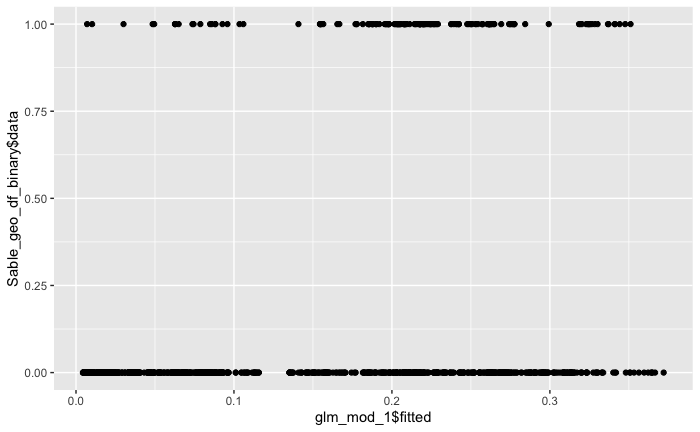

```r
ggplot() + geom_point(aes(glm_mod_1$fitted, Sable_geo_df_binary$data))
```

I think glms are not in bayes though Looks like there are spatial trends

AND I need to check for spatial autocorrelation

OK… Trying spbayes

```r
library(spBayes)
```

Which fucntions do I need? spMvGLm fits multivariate Bayesian generalized linear spatioal regression models -> might be this one

spGLM - > best one yet. OR GLM USE THIS ONE!!

```r
?spGLM
#how to do a spatial logitic regression with this thoug?
#phi <-
#sigma_sq <-
```

Before I do this tho, I think I need to go through the process where I esitmate a phi and sigma squared without using bayesian techniques. I think this is HW 3 and 4, with scallops and wolfcamp FREQUENTIST WORLDVIEW

```r
sable_WLS_tao
```

```
[1] 0.06592581
```

Add other frequentist models?

```r
#add other
```

AND check for spatial autocorrelation!! How to do this again? A variogram??

BACK To BAYESIAN spGLM

```r
#my binary dataframe:
##Sable_geo_df_binary

#phi <- 3/50 #i think I need to find estimates for these
#sigma.sq <- 2


####some other stuff above, not sure how important
m.1 <- spGLM(data~LONGITUDE + LATITUDE, family="binomial", coords=coords, weights=weights, starting=list("beta"=beta.starting, "phi"=0.06,"sigma.sq"=1, "w"=0),
                 tuning=list("beta"=beta.tuning, "phi"=0.5, "sigma.sq"=0.5, "w"=0.5),
priors=list("beta.Normal"=list(0,10), "phi.Unif"=c(0.03, 0.3), "sigma.sq.IG"=c(2, 1)), amcmc=list("n.batch"=n.batch, "batch.length"=batch.length, "accept.rate"=0.43),
                 cov.model="exponential", verbose=TRUE, n.report=10)
```

```r
m.3 <- spGLM(data~LONGITUDE + LATITUDE, family="binomial", coords=Sable_geo_binary$coords, data=Sable_geo_df_binary, n.samples = 100, cov.model="exponential",
             starting=list("phi"=0.5,"sigma.sq"=1), priors=list("phi.Unif"=c(0.03, 0.3), "sigma.sq.IG"=c(2,1)), tuning=list("phi"=0.5, "sigma.sq"=0.5)) # starting=list("beta"=beta.starting, "phi"=0.06,"sigma.sq"=1), #need to add somehthing here!! ##what is beta starting
```

```
w is not specified in starting value list. Setting starting value to 0.Error in spGLM(data ~ LONGITUDE + LATITUDE, family = "binomial", coords = Sable_geo_binary$coords,  :
  error: beta must be specified in tuning value list
```

Epiphany: bayesian 04/06/22 p. 37 of spBayes documentation what does w equal again? sigma/tao? w=taosq/sigmasq!!!!

```r
m.4 <- spGLM(data~LONGITUDE + LATITUDE, family="binomial", coords=Sable_geo_binary$coords, data=Sable_geo_df_binary, n.samples = 100, cov.model="exponential",
             starting=list("phi"=sable_WLS_phi,"sigma.sq"=sable_WLS_sigsq, "beta"=beta.starting, "w"= sable_WLS_w), priors=list("phi.Unif"=c(1, 2), "sigma.sq.IG"=c(2,1),
                                                                                                                                #"beta.Normal"=list(0,10)),
                                                                                                                          "beta.Normal"=list(c(0,0,0),c(10,10,10))),
             tuning=list("phi"=0.5, "sigma.sq"=0.5, "beta"= beta.tuning, "w" = 0.5), #for metropolis proposals. May need to adjust
  amcmc=list("n.batch"=n.batch, "batch.length"=batch.length, "accept.rate"=0.43),
                 verbose=TRUE, n.report=10)
```

```
----------------------------------------
    General model description
----------------------------------------
Model fit with 1150 observations.

Number of covariates 3 (including intercept if specified).

Using the exponential spatial correlation model.

Number of MCMC samples 10000.

Priors and hyperpriors:
    beta normal:
        mu: 0.000   0.000   0.000
        sd: 10.000  10.000  10.000


    sigma.sq IG hyperpriors shape=2.00000 and scale=1.00000

    phi Unif hyperpriors a=1.00000 and b=2.00000

Adaptive Metropolis with target acceptance rate: 43.0
-------------------------------------------------
        Sampling
-------------------------------------------------
```

```
Error in spGLM(data ~ LONGITUDE + LATITUDE, family = "binomial", coords = Sable_geo_binary$coords,  :
  c++ error: Cholesky failed in spGLM
```

04/07/22 Yesterday I figured out my starting values. I keep getting this code: Cholesky failed in spGLM. This could mean it’s failing due to overlapping values. I’ll try making a new dataframe without duplicates, find new parameters for this, and basically just run everything again.

Steps: 1- create new df without duplicates 2- emprical varigram and WLS parameter estimates 3- logistic regression, for beta values (GLM) 4- and then see if the spGLM runs

1. Create new df without duplicates

```r
dup.coords(Sable_geo_df_jitter)
```